# Traffic Data Analysis

```r
library(ggplot2)
library(dplyr)
library(ggmap)
library(rmarkdown)
library(knitr)
```

# Reading data from csv file

```r
data.all <- read.csv(file="all-semi-unique.csv",head=TRUE,sep=",")
summary(data.all)
```

```
##                         crawl_date         ad.aid        ad.bgcl
##  Sun Feb 14 22:30:08 UTC 2016:   120   Min.   :2538   #003768:429982
##  Sun Feb 14 22:30:10 UTC 2016:   120   1st Qu.:2538
##  Sun Feb 14 22:30:11 UTC 2016:   120   Median :2538
##  Sun Feb 14 22:30:14 UTC 2016:   120   Mean   :2538
##  Sun Feb 14 22:30:15 UTC 2016:   120   3rd Qu.:2538
##  Sun Feb 14 23:00:09 UTC 2016:   120   Max.   :2538
##  (Other)                     :429262
##     ad.bgcls         ad.fncl          ad.fncls          ad.lid
##  #0069aa:429982   #FFFFFF:429982   #FFFFFF:429982   Min.   :1001
##                                                     1st Qu.:1001
##                                                     Median :1001
##                                                     Mean   :1001
##                                                     3rd Qu.:1001
##                                                     Max.   :1001
##
##                                                      ad.logo
##  http://www.bey2ollak.com/downloads/logos/Pepsi_SA7EL.png:429982
##
##
##
##
##
##
##                                                        ad.logo2x
##  http://www.bey2ollak.com/downloads/logos/Pepsi_SA7EL@2x.png:429982
##
##
##
##
##
##
##                                                            ad.logoAndroidS
##  http://www.bey2ollak.com/downloads/logos/Pepsi_SA7EL_ANDROID_S.png:429982
##
##
##
##
##
##
```

[output cut: 57 more lines]

```
##  Min.   : 0.0   Min.   : 1.00   lazeez       : 76106   Min.   :9271509
##  1st Qu.:14.0   1st Qu.: 2.00   mashy        : 21710   1st Qu.:9338581
##  Median :29.0   Median : 3.00   7alawa       : 16996   Median :9376096
##  Mean   :29.2   Mean   : 4.71   za7ma        : 14183   Mean   :9376278
##  3rd Qu.:44.0   3rd Qu.:10.00   Eih el nezam?: 14127   3rd Qu.:9413977
##  Max.   :59.0   Max.   :10.00   mafeesh amal :  7904   Max.   :9452302
##                 NA's   :13965   (Other)      :278956
##   rd.rp.rpImg       rd.rp.img        rd.rp.type
##  Min.   : 21970   Min.   :    50   Min.   :0
##  1st Qu.:458600   1st Qu.: 62923   1st Qu.:0
##  Median :461455   Median : 62923   Median :0
##  Mean   :461014   Mean   :146707   Mean   :0
##  3rd Qu.:464205   3rd Qu.:233366   3rd Qu.:0
##  Max.   :467309   Max.   :467247   Max.   :0
##  NA's   :411585   NA's   :152557
```

Check dimensions of the data

```r
dim(data.all)
```

```
## [1] 429982     34
```

Check columns with one unique value

```r
unique.cols.cnt = sapply(data.all, function(x) length(unique(x)))
unique.cols.cnt
```

```
##      crawl_date          ad.aid         ad.bgcl        ad.bgcls
##           28331               1               1               1
##         ad.fncl        ad.fncls          ad.lid         ad.logo
##               1               1               1               1
##       ad.logo2x ad.logoAndroidS ad.logoAndroidH           ad.cm
##               1               1               1               1
##          ad.url            ad.g           rd.nm           rd.ri
##               1               1             301             305
##         rd.stid           rd.hr           rd.mn          rd.new
##              11              71              61               2
##          rd.img           rd.cl         rd.strq         rd.cmrq
##               2               1               2               2
##        rd.rp.nm    rd.rp.fullnm        rd.rp.hr        rd.rp.mn
##           16759           14115              93              60
##      rd.rp.stid        rd.rp.cm      rd.rp.cmid     rd.rp.rpImg
##              11           44716          148367            6277
##       rd.rp.img      rd.rp.type
##            6660               1
```

From the data, it is clear that all the advertisement columns in addition to the “rd.rp.type” and “rd.cl” have only one value and hence can be neglected.

```r
data.multivalue.cols <- data.all[, !names(data.all) %in% names(unique.cols.cnt[unique.cols.cnt==1])]
dim(data.multivalue.cols)
```

```
## [1] 429982     19
```

Before dealing with the NA values and duplicated rows, the semantic meaning of the columns’ names has to be investigated first. After observing the html files of the crawled website, the potential meanings of the columns’ names can be summarized in the following table:

```r
lbl<-c(1,2,3,4,5,6,7,8,9,10)
mng<-c("halawa","laziz","mashy","zahma","mafish amal","Question","Radar/Lagna","Aaccident","Construction","Automatic report")
tbl<-cbind(lbl,mng)
tbl%>%kable()
```

| lbl | mng |
| --- | --- |
| 1 | halawa |
| 2 | laziz |
| 3 | mashy |
| 4 | zahma |
| 5 | mafish amal |
| 6 | Question |
| 7 | Radar/Lagna |
| 8 | Aaccident |
| 9 | Construction |
| 10 | Automatic report |

Let’s remove the duplicate rows accorrding to the rd.rp.cmid

```r
data.noduplicatedrows <- data.multivalue.cols[!duplicated(data.multivalue.cols$rd.rp.cmid),]
dim(data.noduplicatedrows)
```

```
## [1] 148367     19
```

The number of rows is reduced drastically Now that all the columns have 2 or more unique values, let’s have a look on the NA’s

```r
nas.cnt = sapply(data.noduplicatedrows, function(x) sum(is.na(x)))
nas.cnt
```

```
##   crawl_date        rd.nm        rd.ri      rd.stid        rd.hr
##            0            0            0         9890          454
##        rd.mn       rd.new       rd.img      rd.strq      rd.cmrq
##          454            0       130225            0            0
##     rd.rp.nm rd.rp.fullnm     rd.rp.hr     rd.rp.mn   rd.rp.stid
##            0        18082            0            0         4452
##     rd.rp.cm   rd.rp.cmid  rd.rp.rpImg    rd.rp.img
##            0            0       142085        52764
```

Before excluding the rd.rp.fullnm because it adds no information especially that the username is given by the rd.rp.nm column, let’s check on the percentage of users who choose a full name:

```r
users.total <- length(unique(data.noduplicatedrows$rd.rp.nm))
cat("Total number of unique users: ",users.total)
```

```
## Total number of unique users:  16752
```

```r
cat("Percentage of users with a full name:", length(unique(data.noduplicatedrows$rd.rp.fullnm))/users.total)
```

```
## Percentage of users with a full name: 0.8422278
```

```r
cat("Percentage of users with a profile picture: ",length(unique(data.noduplicatedrows$rd.rp.img))/users.total)
```

```
## Percentage of users with a profile picture:  0.3973854
```

Let’s remove the rd.rp.fullnm and rd.rp.img columns

```r
data.rm.nas <- data.noduplicatedrows[ , !(names(data.noduplicatedrows) %in% c("rd.rp.fullnm","rd.rp.img"))]
dim(data.rm.nas)
```

```
## [1] 148367     17
```

```r
nas.cnt = sapply(data.rm.nas, function(x) sum(is.na(x)))
nas.cnt
```

```
##  crawl_date       rd.nm       rd.ri     rd.stid       rd.hr       rd.mn
##           0           0           0        9890         454         454
##      rd.new      rd.img     rd.strq     rd.cmrq    rd.rp.nm    rd.rp.hr
##           0      130225           0           0           0           0
##    rd.rp.mn  rd.rp.stid    rd.rp.cm  rd.rp.cmid rd.rp.rpImg
##           0        4452           0           0      142085
```

Now let’s examine the rd.rp.rpImg column which indicates that teh report has an image attached to it.

```r
nas.cnt["rd.rp.rpImg"]/nrow(data.noduplicatedrows)
```

```
## rd.rp.rpImg
##    0.957659
```

Hence, the percentage of people not attaching a photo to the report is great. Let’s examine the common staus of roads when people usually attach an image

```r
attached.images <- data.rm.nas %>% filter(!is.na(rd.rp.rpImg)) %>% select(rd.rp.stid) %>% group_by(rd.rp.stid) %>% summarise(n=n()) %>% arrange(desc(n))
temp <- (data.rm.nas %>% filter(!is.na(rd.rp.rpImg)) %>% select(rd.rp.stid) %>% filter(!is.na(rd.rp.stid)))
attached.images
```

```
## Source: local data frame [11 x 2]
##
##    rd.rp.stid     n
##         (int) (int)
## 1           2  3947
## 2           3   717
## 3           4   680
## 4           1   543
## 5           5   274
## 6          10    91
## 7           8    11
## 8           9     9
## 9          NA     6
## 10          7     3
## 11          6     1
```

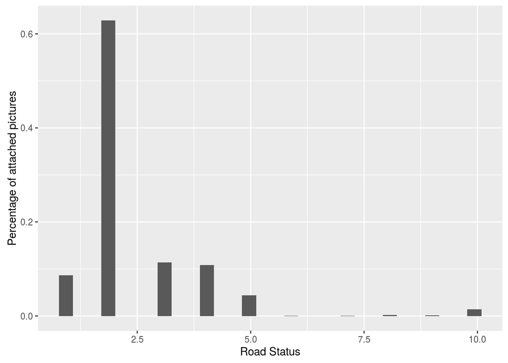

```r
ggplot() + geom_histogram(data = temp, aes(x=rd.rp.stid,y = (..count..)/sum(..count..)))+scale_x_continuous(name="Road Status")+scale_y_continuous(name="Percentage of attached pictures")
```

From the plot it is clear that people tend to post pictures indicating empty roads rather than blocked roads.

No let’s keep dealing with the NA values of the data. The three columns rd.stid, rd.hr and rd.mn do not add any extra information about the roads and are considered redundant since they are aggregation of data of reports. So they are removed along with rd.rp.rpImg after extracting meaningful information from it in previous steps

also removed rd.img column temporarly because its meaning is not clear so far and contains many NAs.

```r
data.rm.nas2 <- data.rm.nas[ , !(names(data.rm.nas) %in% c("rd.stid", "rd.hr" , "rd.mn","rd.rp.rpImg","rd.img"))]
dim(data.rm.nas2)
```

```
## [1] 148367     12
```

```r
nas.cnt = sapply(data.rm.nas2, function(x) sum(is.na(x)))
nas.cnt
```

```
## crawl_date      rd.nm      rd.ri     rd.new    rd.strq    rd.cmrq
##          0          0          0          0          0          0
##   rd.rp.nm   rd.rp.hr   rd.rp.mn rd.rp.stid   rd.rp.cm rd.rp.cmid
##          0          0          0       4452          0          0
```

Ultimately, only one column rd.rp.stid still contains NAs, let’s have a look on some of the rows with NA value in that column:

```r
data.na.stid <- data.rm.nas2 %>% filter(is.na(rd.rp.stid))
data.valid.stid <- data.rm.nas2 %>% filter(!is.na(rd.rp.stid))
temp<-data.na.stid
dim(temp)
```

```
## [1] 4452   12
```

```r
temp[sample(nrow(temp), 10), ] %>% kable()
```

|  | crawl_date | rd.nm | rd.ri | rd.new | rd.strq | rd.cmrq | rd.rp.nm | rd.rp.hr | rd.rp.mn | rd.rp.stid | rd.rp.cm | rd.rp.cmid |
| --- | --- | --- | --- | --- | --- | --- | --- | --- | --- | --- | --- | --- |
| 1429 | Sat Feb 20 06:30:33 UTC 2016 | Sa7rawy;Cairo To Alex | 307 | 0 | 0 | 1 | yasseralaa.saleh | 14 | 15 | NA | clear to 100 | 9434068 |
| 1793 | Fri Feb 12 13:00:33 UTC 2016 | Sokhna/Gharda2ah Rd.;Cairo To Gharda2ah | 305 | 0 | 0 | 1 | ezzatmagdi27 | 1 | 25 | NA | رادار تاني بعد بوابات الوصول الي السخنة | 9357793 |
| 3083 | Wed Feb 10 13:30:43 UTC 2016 | Sa7rawy;Alex To Cairo | 520 | 0 | 0 | 1 | sameh.elmasry | 0 | 49 | NA | k 40 c | 9342365 |
| 4422 | Mon Feb 15 13:00:02 UTC 2016 | Other Roads | 21 | 0 | 0 | 1 | a1gabbas | 5 | 22 | NA | fayum road | 9379155 |
| 1365 | Fri Feb 19 09:00:33 UTC 2016 | Sa7rawy;Cairo To Alex | 307 | 0 | 0 | 1 | fa3el kheir | 0 | 49 | NA | lagna 149 | 9429895 |
| 2645 | Sun Feb 7 05:00:40 UTC 2016 | Sa7rawy;Alex To Cairo | 520 | 0 | 0 | 1 | haythamelboudy | 0 | 49 | NA | any update | 9311562 |
| 1742 | Thu Feb 11 22:30:32 UTC 2016 | Sokhna/Gharda2ah Rd.;Cairo To Gharda2ah | 305 | 0 | 0 | 1 | Dalia%20Ali | 10 | 42 | NA | fe radar ba3d bawbat el sokhna 3alatol | 9351046 |
| 47 | Sat Feb 6 10:30:34 UTC 2016 | Sa7rawy;Cairo To Alex | 307 | 0 | 0 | 1 | bibo200 | 1 | 33 | NA | clear till 50 | 9306345 |
| 2125 | Sat Feb 6 11:00:34 UTC 2016 | Gharda2ah/Sokhna Rd.; Gharda2ah To Cairo | 306 | 0 | 0 | 1 | Manhawy | 1 | 29 | NA | any radar on Soukhna road? from Shoukna to Cairo? | 9306556 |
| 2743 | Sun Feb 7 14:30:44 UTC 2016 | Sa7rawy;Alex To Cairo | 520 | 0 | 0 | 1 | mmnagui | 0 | 40 | NA | clear till 126 7ad 3arf fe eih ba3d keda | 9316080 |

In order take the temp data frame to open refine, it needs to be exported as a csv file:

```r
write.csv(file="test.csv",x=temp)
```

For some reason, open refine does not compute the clusters as shown in the screenshot:

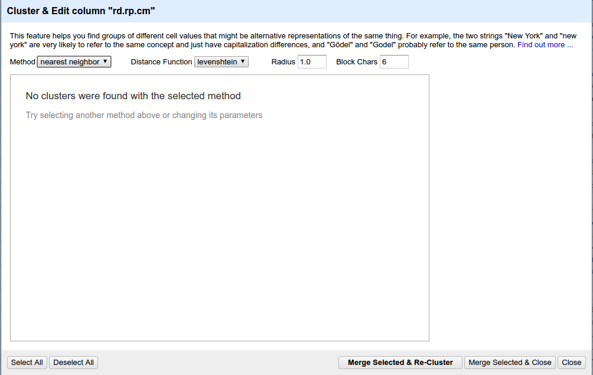

This is why we needed to impute the missing NAs through some other way. The following commands were tested:

```r
library("DMwR")
clean.data <- knnImputation(data.rm.nas2)

library("VIM")
clean.data <- irmi(data.rm.nas2)
```

The first approach tries to find similar rows as each of the ones containing a NA value in the rd.rp.stid column. However through manual inspection, it was clear that the assigned values for rd.rp.stid were mis-leading since the algorithm uses Gower’s algorithm as the distance metric which performs poorly with string such as the ons n the rd.rp.cm column.

The other approach tries to build a predictive regression model and predict the missing values for the rd.rp.stid column, however it performed also poorly after manual inspection.

Thus, another approach had to be implemented in order to check the Levenshtein Distance between the comments of the reports, just as open refine would have done it. This was achieved through the following function calls: Remember that the data is divided on the two data frames data.na.stid and data.valid.stid where the first contains all the rows with NAs in the stid column and the latter contains the rest:

```r
cm.indecies <- amatch(data.na.stid$rd.rp.cm, data.valid.stid$rd.rp.cm, nomatch = NA_integer_, matchNA = TRUE, method = "lv",
       useBytes = FALSE, weight = c(d = 1, i = 1, s = 1, t = 1), maxDist = 100,
       q = 1, p = 0, nthread = getOption("sd_num_thread"))
```

```r
cm.indecies <- read.csv(file="indecies.csv",head=TRUE,sep=",")
cmp.cm <- data.na.stid
cmp.cm <- cmp.cm %>% mutate(Index=cm.indecies[,2])
cmp.cm <- cmp.cm %>% mutate(cmp.rp.cm=data.valid.stid$rd.rp.cm[Index])
cmp.cm <- cmp.cm %>% mutate(cmp.rp.stid=data.valid.stid$rd.rp.stid[Index])
cmp.cm$rd.rp.stid <- cmp.cm$cmp.rp.stid

cmp.cm %>% select("Actual comment"=rd.rp.cm,"Matched comment"=cmp.rp.cm,"Imputed stid"=rd.rp.stid) %>% head(n=20) %>% kable()
```

| Actual comment | Matched comment | Imputed stid |
| --- | --- | --- |
| rader @km140 | radar @ k147 | 2 |
| حلاوه للنوباريه | فل لحد النوباريه | 1 |
| clear from km 140 to master | clear from km 173 till master | 1 |
| any radars from master to gates? | any radars from Sokhna to Cairo? | 6 |
| clear to abo el matamir | clear to alex gates | 1 |
| 140 kamin maba7es mesh radar | eh akhbar el radar | 6 |
| مافيش شبوره | ما فيش حركه | 5 |
| hwa feh radar ? | mafesh radar? | 6 |
| فى شبوره ولا؟ | فى ايه ؟؟؟ | 6 |
| sadat radar kilo 150 rawa7 | radar kilo 150 | 5 |
| clear from km140 to gates | clear from gate to gate | 1 |
| k kam el radar?? | eh a5bar el radar? | 6 |
| any radar from 140 km to bawabat | any radar from Alex to cairo | 6 |
| مول المعداوي | مول العجمي | 4 |
| sry ya regala tel3et lagna msh radar | sokhna gate to gate clear no radar | 10 |
| ايه اخبار الرادار يا شباب | ايه اخبار الطريق يا شباب | 5 |
| untill 170 clear | till 56 clear | 2 |
| radars ? | radars? | 6 |
| just left bawabat Cairo | el bawabab za7ma | 5 |
| up dates plz | updates plz | 6 |

The code above looks for the minimum Levenshtein Distance for each comment in data.na.stid in the set of comments from data.valid.stid and assigns it to the respective rd.rp.stid. Let’s combine the all the rows together:

```r
data.semi.ready <- rbind(cmp.cm[,!(names(cmp.cm) %in% c("Index", "cmp.rp.cm" , "cmp.rp.stid"))] %>% filter(!is.na(cmp.cm$rd.rp.stid)),data.valid.stid)
summary(data.semi.ready)
```

```
##                         crawl_date
##  Sun Feb 14 22:30:08 UTC 2016:   120
##  Sun Feb 14 22:30:10 UTC 2016:   120
##  Sun Feb 14 22:30:11 UTC 2016:   120
##  Sun Feb 14 22:30:15 UTC 2016:   120
##  Sun Feb  7 22:30:18 UTC 2016:   120
##  Sun Feb  7 22:30:25 UTC 2016:   120
##  (Other)                     :147644
##                                     rd.nm            rd.ri
##  Kobry 6 October;Madinet Nasr To Ta7rir:  3218   Min.   :  5
##  Da2ery;Moneeb To Autostrad            :  3075   1st Qu.:148
##  Da2ery;Autostrad To Moneeb            :  2998   Median :254
##  Kobry 6 October;Mohandesin To Ta7rir  :  2862   Mean   :294
##  Sa7rawy;Alex To Cairo                 :  2620   3rd Qu.:475
##  Sa7rawy;Cairo To Alex                 :  2319   Max.   :699
##  (Other)                               :131272
##      rd.new           rd.strq          rd.cmrq
##  Min.   :0.00000   Min.   :0.0000   Min.   :0.0000
##  1st Qu.:0.00000   1st Qu.:1.0000   1st Qu.:0.0000
##  Median :0.00000   Median :1.0000   Median :0.0000
##  Mean   :0.07021   Mean   :0.9533   Mean   :0.0679
##  3rd Qu.:0.00000   3rd Qu.:1.0000   3rd Qu.:0.0000
##  Max.   :1.00000   Max.   :1.0000   Max.   :1.0000
##
##                 rd.rp.nm        rd.rp.hr          rd.rp.mn
##  bey2ollakgps       :58295   Min.   :  0.000   Min.   : 0.0
##  fa3el kheir        :14690   1st Qu.:  1.000   1st Qu.:13.0
##  SuperSafwat        :  612   Median :  5.000   Median :27.0
##  waleedm            :  481   Mean   :  8.036   Mean   :28.1
##  Tootchy            :  465   3rd Qu.: 13.000   3rd Qu.:43.0
##  kareemabdelkareem90:  428   Max.   :139.000   Max.   :59.0
##  (Other)            :73393
##    rd.rp.stid              rd.rp.cm       rd.rp.cmid
##  Min.   : 1.000   lazeez       :25871   Min.   :9271509
##  1st Qu.: 2.000   mashy        : 7396   1st Qu.:9338152
##  Median : 3.000   7alawa       : 5773   Median :9376326
##  Mean   : 4.709   za7ma        : 4917   Mean   :9376245
##  3rd Qu.: 8.000   Eih el nezam?: 4863   3rd Qu.:9414324
##  Max.   :10.000   mafeesh amal : 2926   Max.   :9452302
##                   (Other)      :96618
```

```r
data.test <- data.semi.ready
data.test$crawl_date <- as.POSIXct(data.test$crawl_date,format = "%a %b  %d %H:%M:%S",tz = "UTC")
data.semi.ready <- data.semi.ready %>% mutate(report.time= data.test$crawl_date -(data.test$rd.rp.hr * 60 * 60) - (data.test$rd.rp.mn * 60))
data.semi.ready <- data.semi.ready %>% mutate(report.time.hrs= format(report.time, format="%y-%m-%d %H"))
data.semi.ready <- data.semi.ready %>% mutate(report.time.day= format(report.time, format="%y-%m-%d"))
data.semi.ready <- data.semi.ready %>% mutate(report.time.hour= format(report.time, format="%H"))
data.semi.ready <- data.semi.ready %>% mutate(report.time.hrs.round= format(round(report.time, units="hours"), format="%y-%m-%d %H"))
```

Divide the name to a location and a direction

```r
temp.split<-data.frame(strsplit(as.character(data.semi.ready$rd.nm), "[;]"))
temp.split.t<-t(temp.split)
data.semi.ready<-data.semi.ready%>%mutate(location=temp.split.t[,1],direction=temp.split.t[,2])
data.semi.ready[sample(nrow(data.semi.ready), 10), ]
```

```
##                          crawl_date
## 26247  Tue Feb 16 00:00:14 UTC 2016
## 25950  Mon Feb  8 16:30:16 UTC 2016
## 96922  Thu Feb 18 16:00:15 UTC 2016
## 7311   Tue Feb  9 12:00:02 UTC 2016
## 108475 Thu Feb 18 22:30:29 UTC 2016
## 90297  Thu Feb 11 22:30:16 UTC 2016
## 49390  Wed Feb 10 05:30:25 UTC 2016
## 31401  Tue Feb 16 07:00:29 UTC 2016
## 8150   Sun Feb 14 15:30:03 UTC 2016
## 10422  Fri Feb 12 21:00:11 UTC 2016
##                                            rd.nm rd.ri rd.new rd.strq
## 26247      Kornich ElNile;West ElBalad To Da2ery   168      0       1
## 25950      Kornich ElNile;West ElBalad To Da2ery   168      0       1
## 96922       Kobry 6 October;Ta7rir To Mohandesin   167      0       1
```

[output cut: 62 more lines]

Do the same to get from and to

```r
temp.split <- t(data.frame(strsplit(as.character(data.semi.ready$direction), " To ")))
data.semi.ready<-data.semi.ready%>%mutate(from=temp.split[,1],to=temp.split[,2])
data.semi.ready[sample(nrow(data.semi.ready), 10), ]
```

```
##                          crawl_date                                  rd.nm
## 93620  Wed Feb 10 06:01:06 UTC 2016               45 St;Kobry 45 To ElBa7r
## 120871 Sat Feb 20 19:30:22 UTC 2016  Me7war Sa3d ElShazly;Da2ery To 3obour
## 38404  Tue Feb  9 13:30:16 UTC 2016   Sala7 Salem;Kobry 6 October To 2al3a
## 6823   Sat Feb  6 16:00:02 UTC 2016             Da2ery;Moneeb To Autostrad
## 133055 Mon Feb  8 14:30:35 UTC 2016             Da2ery;Tagamo3 To Suez Rd.
## 145707 Wed Feb 17 17:30:15 UTC 2016 Kobry 6 October;Madinet Nasr To Ta7rir
## 71970  Thu Feb 11 22:30:29 UTC 2016         Da2ery;Nafa2 ElSalam To Zera3y
## 4391   Sun Feb 21 08:30:41 UTC 2016                  Sa7rawy;Alex To Cairo
## 96815  Thu Feb 18 07:00:15 UTC 2016   Kobry 6 October;Ta7rir To Mohandesin
## 142500 Sun Feb  7 22:31:02 UTC 2016             Zera3y Road;Tanta To Banha
##        rd.ri rd.new rd.strq rd.cmrq          rd.rp.nm rd.rp.hr rd.rp.mn
## 93620    653      0       1       0      selim.elbahz       36       43
## 120871   227      0       1       0         AymanEyad       23       18
## 38404    176      0       1       0 chanceforlove_212       17       25
```

[output cut: 62 more lines]

Now let’s divide the data into 2 categories: the first one is direct user reports having an stid from 1-5 and the other gropu is informative reports having stid from 6-10:

```r
data.rpts <- data.semi.ready%>%filter(rd.rp.stid %in% c(1,2,3,4,5))
data.info <- data.semi.ready%>%filter(rd.rp.stid %in% c(6,7,8,9,10))
```

Examining the road with the highest reported accidents. The examination will proceed with eliminating the repeated reports of any accident, assuming that any accient is not reported twice within one hour, then accumilating the number of accidents for one road.

```r
temp.accidents <- data.info %>% filter(rd.rp.stid==8)
nrow(temp.accidents)
```

```
## [1] 281
```

```r
temp.accidents <- temp.accidents[!duplicated(temp.accidents$report.time.hrs,temp.accidents$rd.nm),]
data.accidents <- temp.accidents%>%group_by(location)%>%summarise(n=n())%>%arrange(desc(n))
nrow(data.accidents)
```

```
## [1] 26
```

```r
data.accidents %>% kable()
```

| location | n |
| --- | --- |
| Da2ery | 44 |
| Zera3y Road | 23 |
| Sala7 Salem | 10 |
| Sa7rawy | 9 |
| Me7war | 8 |
| Suez Rd. | 8 |
| Autostrad | 6 |
| Ismailia Rd. | 6 |
| Ismailia Road | 5 |
| Kobry 6 October | 4 |
| Me7war Saft ElLaban | 4 |
| NA Road | 4 |
| Sokhna/Gharda2ah Rd. | 3 |
| Wahat Road | 3 |
| El Wasla | 2 |
| Kornich ElNile | 2 |
| Mansoureya | 2 |
| 90 St. | 1 |
| Ba7r A3zam | 1 |
| ElBa7r | 1 |
| Kobry 15 Mayo | 1 |
| Me7war Ahmed 3orabi | 1 |
| Me7war ElKhalafawy | 1 |
| Me7war ElShaheed | 1 |
| Sidi Gaber | 1 |
| Tari2 El 3agamy | 1 |

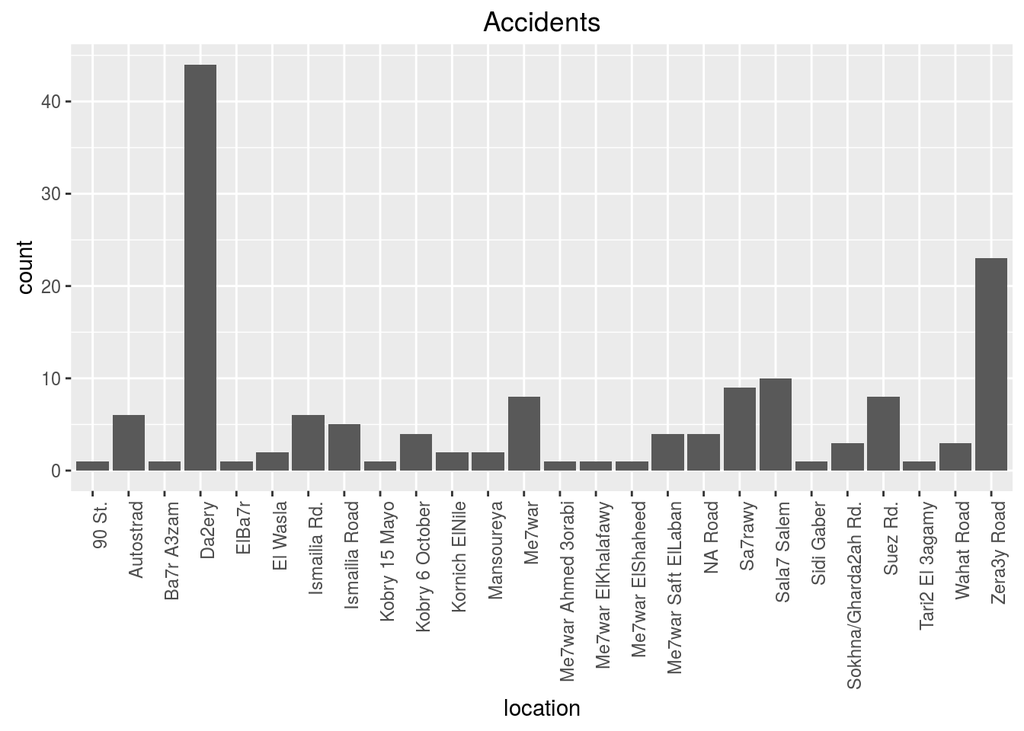

```r
ggplot(data = temp.accidents, aes(x=location)) + geom_bar()+labs(title="Accidents")+ geom_bar()+ theme(axis.text.x = element_text(angle = 90, hjust = 1))
```

Examining the number of reports with respect to the road for radars and checkpoints

```r
temp.radars <- data.info %>% filter(rd.rp.stid==7)
nrow(temp.radars)
```

```
## [1] 349
```

```r
temp.temp <- temp.radars[!duplicated(temp.radars$report.time.hrs,temp.accidents$rd.nm),]
data.radars <- temp.radars%>%group_by(location)%>%summarise(n=n())%>%arrange(desc(n))
nrow(data.radars)
```

```
## [1] 22
```

```r
data.radars %>% kable()
```

| location | n |
| --- | --- |
| Sa7rawy | 153 |
| Sokhna/Gharda2ah Rd. | 54 |
| Da2ery | 31 |
| Me7war | 21 |
| Zera3y Road | 14 |
| Autostrad | 12 |
| El Wasla | 12 |
| Gharda2ah/Sokhna Rd. | 12 |
| Suez Rd. | 8 |
| Kobry 6 October | 7 |
| Kobry 15 Mayo | 4 |
| Kornich ElNile | 4 |
| NA Road | 4 |
| Sala7 Salem | 4 |
| Ismailia Rd. | 2 |
| ElBa7r | 1 |
| Kobry Kasr ElNile | 1 |
| Me7war Ahmed 3orabi | 1 |
| Me7war ElShaheed | 1 |
| Nafa2 ElAzhar | 1 |
| Ta7t K.October(Lotfy ElSayed) | 1 |
| Wahat Road | 1 |

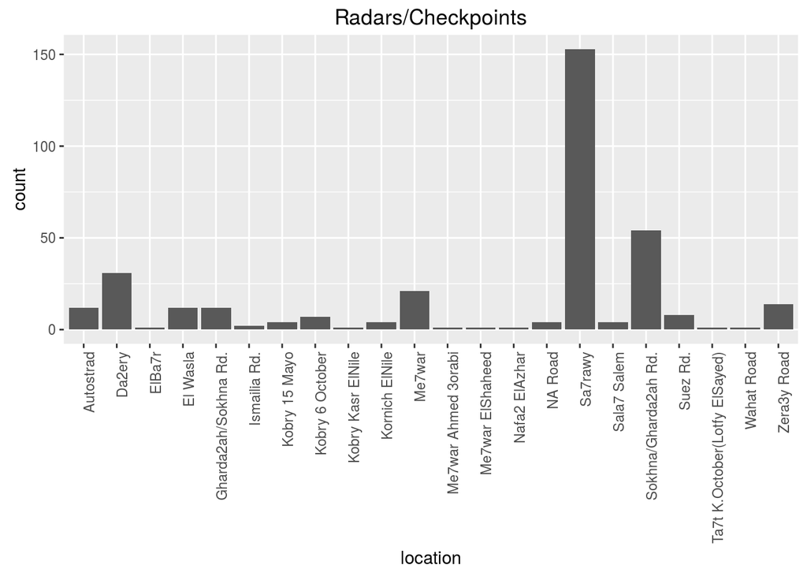

```r
ggplot(data = temp.radars, aes(x=location)) + geom_bar()+labs(title="Radars/Checkpoints")+ geom_bar()+ theme(axis.text.x = element_text(angle = 90, hjust = 1))
```

Now let’s examine the users’ activities with respect to the time of the day

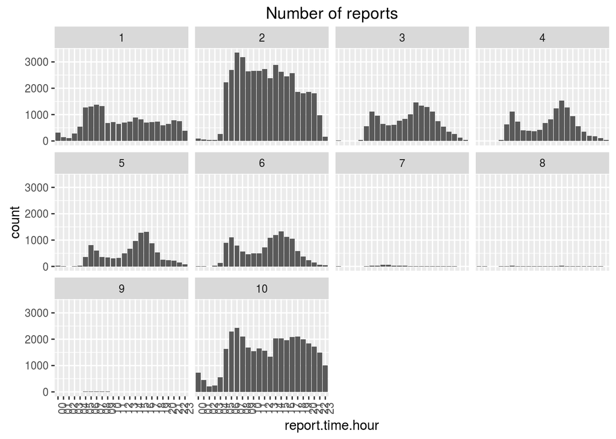

```r
ggplot(data = data.semi.ready, aes(report.time.hour)) + geom_bar()+facet_wrap(~ rd.rp.stid)+labs(title="Number of reports")+ geom_bar()+ theme(axis.text.x = element_text(angle = 90, hjust = 1))
```

The cummilative plot of the plots above is the following

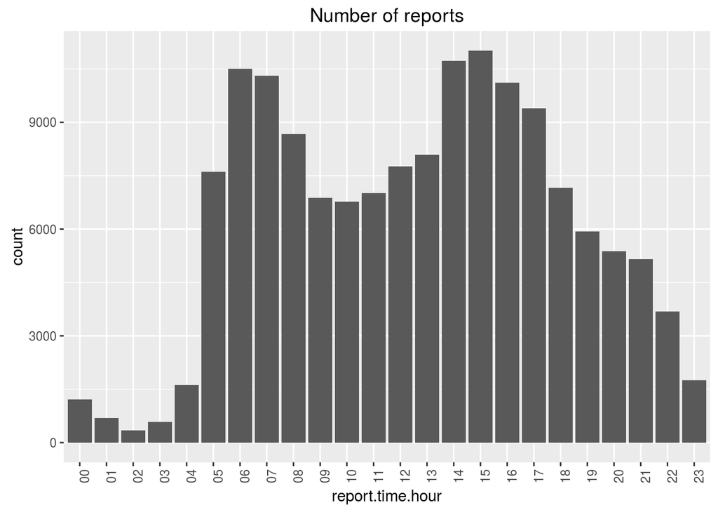

```r
ggplot(data = data.semi.ready, aes(x=report.time.hour)) + geom_bar()+labs(title="Number of reports")+ theme(axis.text.x = element_text(angle = 90, hjust = 1))
```

Notice the two peeks which indicate the peeks reporting.

In order to examine the top reporters on the website, we consider the following table:

```r
data.reporters <- data.semi.ready%>%group_by(rd.rp.nm)%>%summarise(n=n())%>%arrange(desc(n))
nrow(data.reporters)
```

```
## [1] 16752
```

```r
data.reporters %>%head(n=10)%>% kable()
```

| rd.rp.nm | n |
| --- | --- |
| bey2ollakgps | 58295 |
| fa3el kheir | 14690 |
| SuperSafwat | 612 |
| waleedm | 481 |
| Tootchy | 465 |
| kareemabdelkareem90 | 428 |
| ramo_louis | 352 |
| mada68861 | 313 |
| nanos26 | 313 |
| ahmedabdo01 | 311 |

To examine the freqency of reports of single user in one hour, consider the following table

```r
data.reporters <- data.semi.ready%>%group_by(rd.rp.nm,report.time.hrs)%>%summarise(n=n())%>%arrange(desc(n))
nrow(data.reporters)
```

```
## [1] 48957
```

```r
data.reporters %>%head(n=10)%>% kable()
```

| rd.rp.nm | report.time.hrs | n |
| --- | --- | --- |
| 007 | 16-02-15 05 | 29 |
| 007 | 16-02-10 21 | 26 |
| 007 | 16-02-12 08 | 24 |
| 007 | 16-02-16 20 | 23 |
| 007 | 16-02-19 22 | 21 |
| 007 | 16-02-09 05 | 13 |
| 007 | 16-02-18 05 | 12 |
| 007 | 16-02-21 05 | 9 |
| 007 | 16-02-05 14 | 4 |
| 007 | 16-02-07 12 | 3 |

The table shows weird behavior for user “007”, because 29 reports in a single hour is not a logical number. Hence let’s examine those rows carefully:

```r
data.semi.ready %>% filter(rd.rp.nm=="007",report.time.hrs=="16-02-15 05")%>%arrange(desc(report.time))%>%select(report.time,rd.nm,rd.rp.cm)%>%kable()
```

| report.time | rd.nm | rd.rp.cm |
| --- | --- | --- |
| 2016-02-15 05:11:26 | Autostrad;Kobry 6 October To City Stars | 7alawa |
| 2016-02-15 05:11:25 | Autostrad;City Stars To Kobry 6 October | 7alawa |
| 2016-02-15 05:11:00 | Makram 3ebeid;Autostrad To Mostafa ElNa7as | 7alawa |
| 2016-02-15 05:11:00 | Tayaran St.;Sala7 Salem To Sabe3 | 7alawa |
| 2016-02-15 05:10:59 | Mostafa ElNa7as;ElTamen To Kesm Thani | 7alawa |
| 2016-02-15 05:10:59 | 3abbas El3akkad;Autostrad To Zaker 7esein | 7alawa |
| 2016-02-15 05:10:59 | Zaker 7esein;Da2ery To Sabe3 | 7alawa |
| 2016-02-15 05:10:42 | Nozha St;Midan ElSa3a To 7 3omarat | 7alawa |
| 2016-02-15 05:10:16 | Marghani St.;7 3omarat St. To Roxy Sq. | 7alawa |
| 2016-02-15 05:10:15 | Sala7 Salem;2al3a To Kobry 6 October | 7alawa |
| 2016-02-15 05:10:04 | Sala7 Salem;Nafa2 El3orouba To Matar | 7alawa |
| 2016-02-15 05:10:02 | Sala7 Salem;Nafa2 El3orouba To Kobry 6 October | 7alawa |
| 2016-02-15 05:09:16 | Sala7 Salem;2al3a To Kornich ElNile | 7alawa |
| 2016-02-15 05:09:08 | Madinet Nasr | شارع الطيران |
| 2016-02-15 05:09:01 | Mostafa ElNa7as;Kesm Thani To ElTamen | 7alawa |
| 2016-02-15 05:09:01 | Tayaran St.;Sabe3 To Sala7 Salem | 7alawa |
| 2016-02-15 05:09:00 | Makram 3ebeid;Mostafa ElNa7as To Autostrad | 7alawa |
| 2016-02-15 05:09:00 | 3abbas El3akkad;Zaker 7esein To Autostrad | 7alawa |
| 2016-02-15 05:08:59 | Zaker 7esein;Sabe3 To Da2ery | 7alawa |
| 2016-02-15 05:08:42 | Nozha St;7 3omarat To Midan ElSa3a | 7alawa |
| 2016-02-15 05:08:17 | Marghani St.;Roxy Sq. To 7 3omarat | 7alawa |
| 2016-02-15 05:08:15 | Sala7 Salem;Kobry 6 October To 2al3a | 7alawa |
| 2016-02-15 05:08:15 | Sala7 Salem;Kornich ElNile To 2al3a | 7alawa |
| 2016-02-15 05:08:09 | Masr ElGedeeda | شارع الأهرام |
| 2016-02-15 05:08:05 | Sala7 Salem;Kobry 6 October To Nafa2 El3orouba | 7alawa |
| 2016-02-15 05:08:01 | Sala7 Salem;Matar To Nafa2 El3orouba | 7alawa |
| 2016-02-15 05:07:29 | Me7war ElKhalafawy;Kornich To Madinet Nasr | 7alawa |
| 2016-02-15 05:07:28 | Me7war ElKhalafawy;Madinet Nasr To Kornich | 7alawa |
| 2016-02-15 05:07:08 | Nafa2 ElAzhar;Sala7 Salem To West ElBalad | 7alawa |

From the table we can clearly see that this data is not correct and should not be considered for future computations.

In order to monitor the average traffic over the day for a sample roads consider the following two plots:

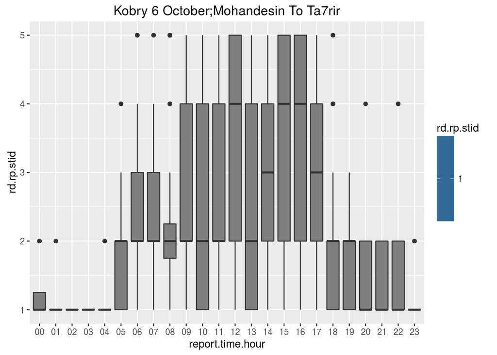

```r
firstPlot <- function(x){
ggplot(data.semi.ready%>%filter(rd.nm==x,rd.rp.stid %in% c(1,2,3,4,5)), aes(x=report.time.hour, y=rd.rp.stid, fill=rd.rp.stid)) + geom_boxplot()+labs(title=x)

}

secondPlot <- function(x){
  t1 <- data.semi.ready%>%filter(rd.nm==x,rd.rp.stid %in% c(1,2,3,4,5))%>%group_by(report.time.hour)%>%summarise(avg=mean(rd.rp.stid),med=median(rd.rp.stid))

ggplot(data = t1, aes(x=report.time.hour,y=avg,group = 1)) + stat_smooth()+labs(title=x)
}

firstPlot("Kobry 6 October;Mohandesin To Ta7rir")
```

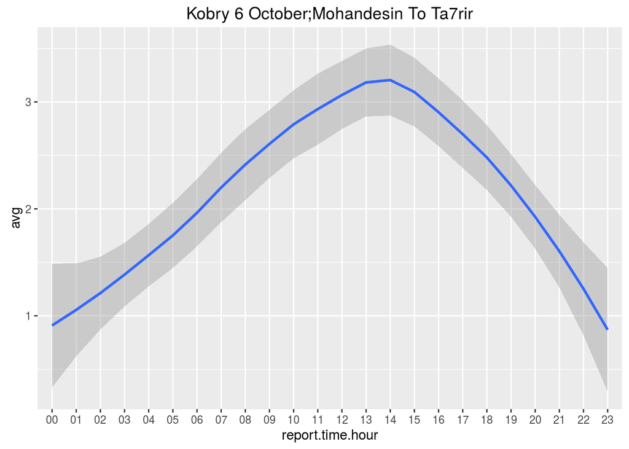

```r
secondPlot("Kobry 6 October;Mohandesin To Ta7rir")
```

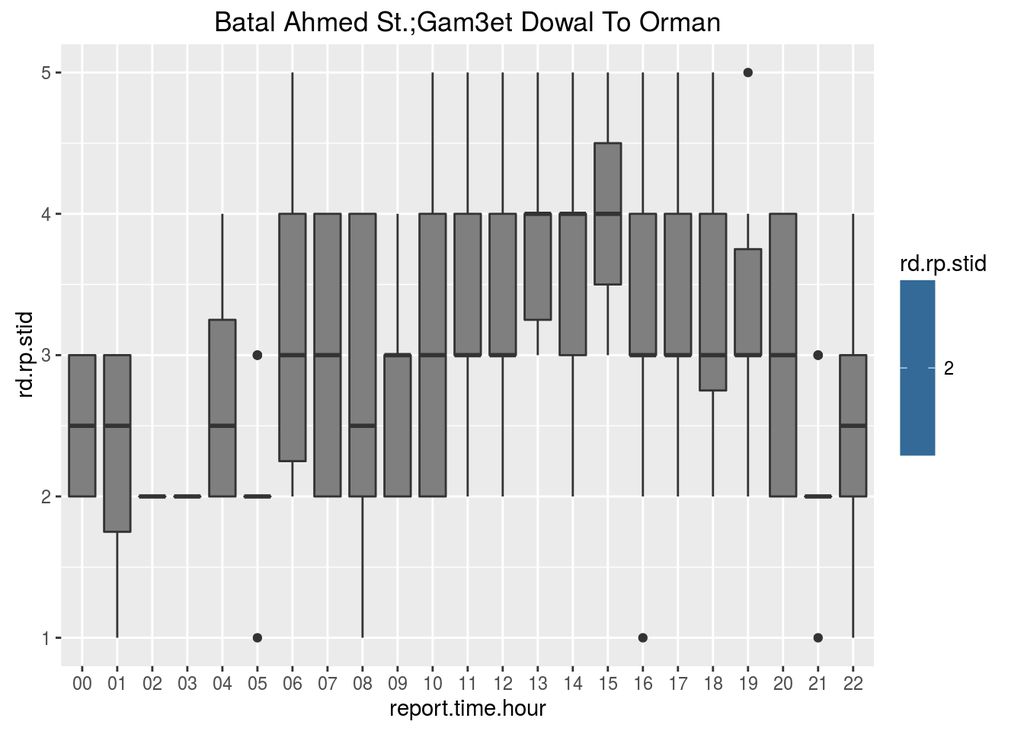

```r
firstPlot("Batal Ahmed St.;Gam3et Dowal To Orman")
```

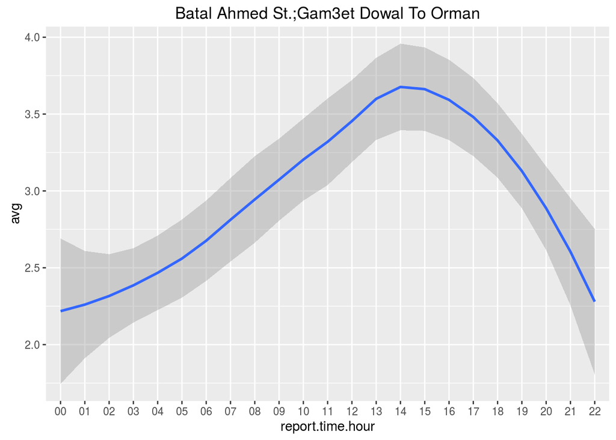

```r
secondPlot("Batal Ahmed St.;Gam3et Dowal To Orman")
```

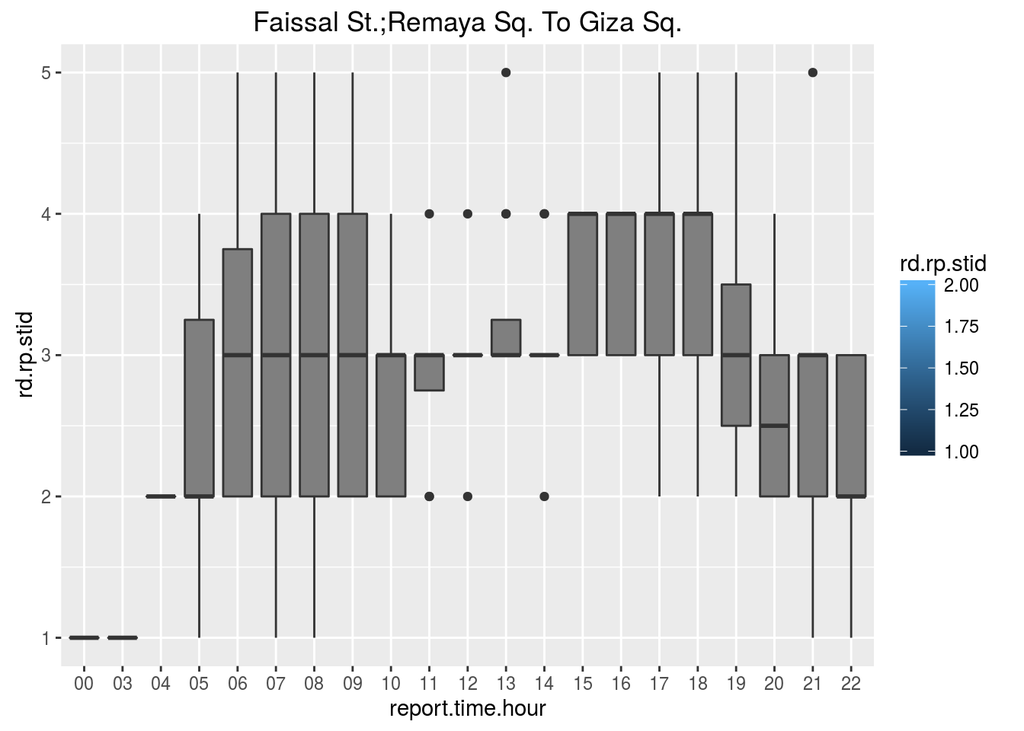

```r
firstPlot("Faissal St.;Remaya Sq. To Giza Sq.")
```

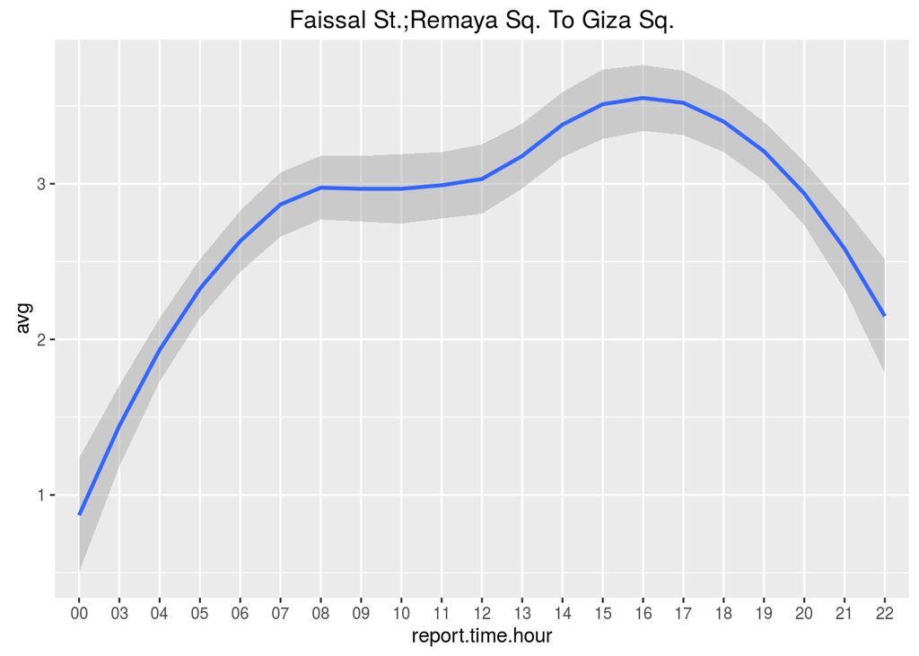

```r
secondPlot("Faissal St.;Remaya Sq. To Giza Sq.")
```

The outliers in the boxplots indicate unclean data points that need to be neglected and the curves of the average lines have the tendency to show heavy traffic during mid day.